# Regulatory Enforcement Actions: Trend & Thematic Analysis

Author

RegBrief Analytics

Published

July 4, 2026

**Q2 2026 | Comprehensive Analysis of AML/Compliance Enforcement Patterns**

# Executive Summary

Across 24 enforcement actions, 20 involved monetary penalties and 4 were resolved without financial sanctions, indicating that regulators used a mix of punitive and non-monetary remedies. The **median penalty was $227,700**, which is a more representative indicator of typical case severity than the headline total. While the **average penalty was $14.5 million**, that figure is heavily distorted by a single outlier: **Adani Enterprises Limited**, which accounted for **$275 million** of the **$289.5 million** total penalties. **Excluding Adani Enterprises Limited, total penalties fall to $14.45 million**, underscoring that most actions were materially smaller than the aggregate suggests.

Geographically, enforcement was highly concentrated in the **United States**, which accounted for **13 actions** and **$285.6 million** of penalties, including the outlier case. The **UK** and **France** represented a much smaller share of monetary exposure, with **$1.59 million** and **$1.42 million** respectively. The data also show involvement from **10 regulators across 6 countries**, suggesting a broad but uneven enforcement footprint. This pattern points to strong U.S.-led enforcement activity, with cross-border implications for firms operating in multiple jurisdictions or with globally distributed compliance obligations.

The most common compliance weaknesses were concentrated in core control functions: **AML Program Governance (44 findings)**, **Investigations & Reporting (38)**, **KYC & Onboarding (36)**, **Transaction Monitoring (24)**, and **Sanctions Screening (21)**. Root-cause analysis reinforces that these are not isolated control failures but systemic issues, led by **Process Design Flaws (46.0%)** and **Governance Failure (27.6%)**. In other words, the dominant issues appear to stem from weak control architecture, unclear accountability, and ineffective escalation/reporting processes rather than isolated execution errors alone.

For financial institutions, the implications are clear: regulators are repeatedly targeting foundational AML and sanctions controls, especially where governance and process design are deficient. Firms should prioritize end-to-end remediation of onboarding, monitoring, and investigative workflows; strengthen board and senior management oversight; and validate that technology, data quality, and staffing are aligned to risk. Given the prevalence of non-monetary resolutions alongside monetary penalties, institutions should also expect regulators to use consent orders and similar undertakings to drive sustained remediation, not just financial punishment.

# Dataset Overview

This analysis examines **24 regulatory enforcement actions** issued in Q2 2026, with sanctioned activity spanning 2014–2026. The dataset covers multiple jurisdictions and financial services sectors and includes detailed compliance findings[^1], root cause analysis, and remediation roadmaps.

## Key Statistics

- **Total Enforcement Actions:** 24 (20 with monetary penalties, 4 non-monetary resolutions)
- **Total Penalties Imposed:** $289,454,604
- **Median Penalty:** $227,700
- **Average Penalty:** $14,472,730
- **Penalty Range:** $17,405 - $275,000,000
- **Countries Represented:** 6
- **Regulators Involved:** 10
- **Industry Sectors:** 7

**WarningOutlier-adjusted view**

A small number of actions dominate the headline total: **Adani Enterprises Limited ($275,000,000, 95% of total)**. Excluding this action, total penalties across the remaining 23 actions are **$14,454,604** (median **$227,700**). The distribution and per-country/per-regulator charts below are read with this concentration in mind.

# Monetary Penalties Analysis

## Total Penalties by Country/Region

The geographic distribution of penalties reveals significant concentration in specific jurisdictions, with enforcement intensity varying considerably across regions.

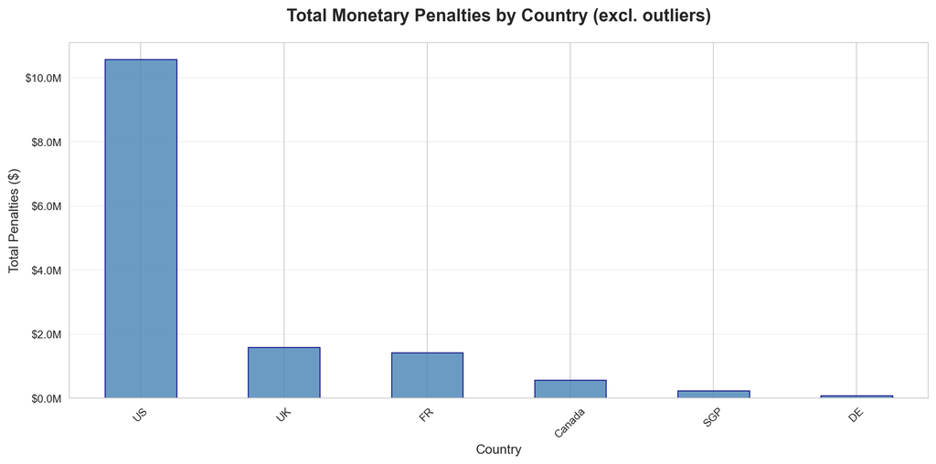

Figure 1: Total monetary penalties by country

*Chart excludes 1 outlier action(s) — Adani Enterprises Limited ($275.0M) — to keep the remaining bars legible. Full totals are in the summary table.*

### Regional Penalties Summary Table

Table 1: Summary of penalties by country

| country | Total Penalties | Average Penalty | Max Penalty | Number of Actions |
| --- | --- | --- | --- | --- |
| US | $285,564,357 | $25,960,396 | 275000000.0 | 13 |
| UK | $1,585,641 | $792,820 | 1361241.0 | 2 |
| France | $1,417,000 | $1,417,000 | 1417000.0 | 1 |
| Canada | $571,106 | $142,777 | 487853.6 | 4 |
| Singapore | $231,000 | $231,000 | 231000.0 | 1 |
| Germany | $85,500 | $85,500 | 85500.0 | 3 |

## Penalties by Regulator

Different regulatory bodies demonstrate varying enforcement approaches and penalty magnitudes.

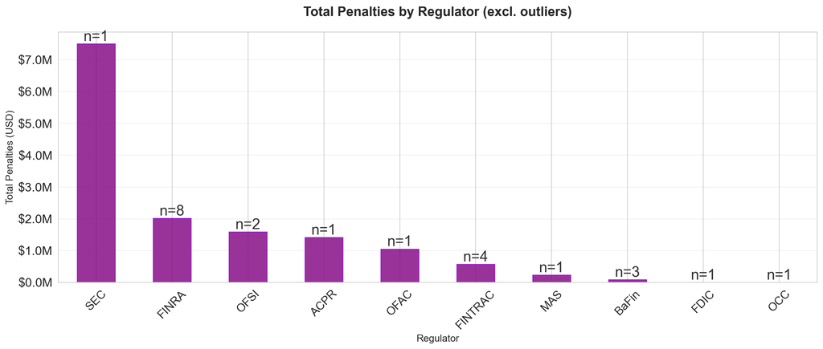

Figure 2: Total penalties by regulatory authority

*Chart excludes 1 outlier action(s) — Adani Enterprises Limited ($275.0M) — to keep the remaining bars legible. Full totals are in the summary table.*

### Regulatory Insights

Enforcement during the period was **generally low-to-moderate in typical case value**, with a **median penalty of $227,700** and only **20 of 24 actions carrying monetary penalties**; the remaining **4 were non-monetary resolutions**. The headline figures are heavily distorted by the outlier **Adani Enterprises Limited**, which alone accounts for **$275,000,000** of the **$289,454,604** total. **Excluding Adani, total penalties fall to $14,454,604**, which is much more representative of the underlying enforcement environment. By regulator, the pattern is highly concentrated: **OFAC** dominates with **$276.05M across 2 actions**, driven by very large sanctions cases; **SEC** follows with a single **$7.5M** action. In contrast, **FINRA** shows a higher-volume, lower-severity profile (**8 actions, $2.01M total; avg. ~$252K**), while **OFSI, ACPR, FINTRAC, MAS, and BaFin** are mostly in the sub-$1.6M range, suggesting more routine supervisory or conduct enforcement rather than blockbuster penalties. Regionally, the **US** accounts for almost all monetary value (**$285.6M across 13 actions**), but that concentration is largely a function of the Adani outlier and OFAC’s large sanctions penalties; outside the US, enforcement is more dispersed and materially smaller in scale.

For multi-jurisdiction compliance programs, the message is to build for **heterogeneous enforcement intensity**: a sanctions-heavy, high-impact U.S. risk profile alongside smaller but more frequent supervisory actions in Europe, the UK, Canada, and Asia. Programs should therefore combine **enterprise-wide controls** (screening, sanctions escalation, trade/financial crime monitoring, disclosure controls) with **local regulatory mapping** for FINRA/SEC, OFAC/OFSI, ACPR/BaFin, FINTRAC, MAS, and prudential agencies like FDIC/OCC. The presence of **non-monetary resolutions** also matters: consent orders and similar outcomes can signal control deficiencies even where no fine is imposed, so remediation tracking should not be penalty-driven alone. Practically, prioritize robust sanctions governance and investigation protocols for U.S./cross-border exposure, while maintaining jurisdiction-specific playbooks for reporting, recordkeeping, and supervisory engagement to manage the more common mid-sized actions seen outside the outlier cases.

## Penalties by Industry Sector

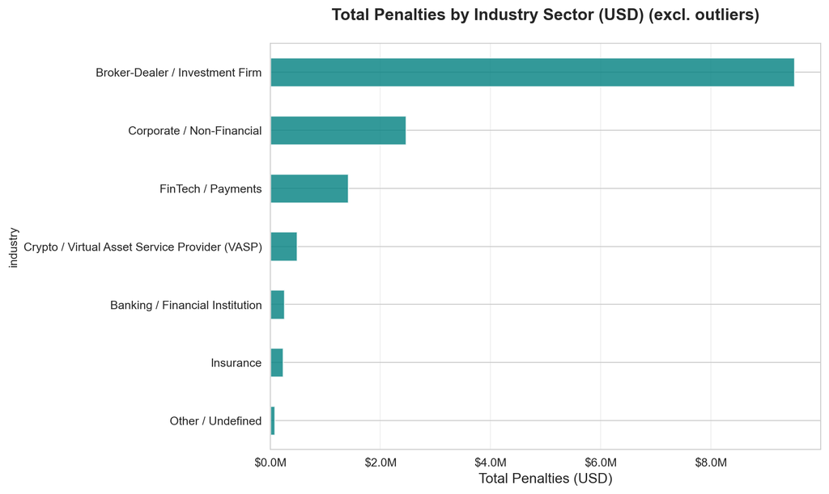

Figure 3: Total penalties by industry sector (USD)

*Chart excludes 1 outlier action(s) — Adani Enterprises Limited ($275.0M) — to keep the remaining bars legible. Full totals are in the summary table.*

### Industry Insights

The clear outlier by total penalty amount is **Corporate / Non-Financial**, with **$277.5M** across just **5 actions**. That means this sector contributes the vast majority of total penalty volume despite not having the highest number of cases, and its **average penalty of $55.5M** is dramatically higher than every other sector. The next largest by total penalties is **Broker-Dealer / Investment Firm** at **$9.5M** across **10 actions**—the highest action count in the table, but still only a small fraction of the total penalty dollars seen in Corporate / Non-Financial. This is a strong example of total penalty volume diverging from action count: broker-dealers are being targeted more frequently, but the corporate/non-financial sector is where the most financially significant enforcement outcomes are concentrated.

The average penalty pattern suggests two very different enforcement profiles. **Corporate / Non-Financial** is highly concentrated in a few large actions, indicating a small number of severe cases rather than broad-based, lower-value enforcement. **FinTech / Payments** also stands out with **$1.417M from a single action**, and **Insurance** shows **$231k from one action**—both indicating one-off, potentially material events. By contrast, **Broker-Dealer / Investment Firm** has **10 actions** but only a **$1.06M average**, suggesting a broader distribution of lower- to mid-sized penalties rather than a few outsized cases. **Banking / Financial Institution** also shows relatively low total penalties (**$254k**) across **5 actions**, reinforcing that not all high-regulation sectors are generating large penalty volumes in this dataset.

Strategically, compliance investment should be prioritised based on both **severity risk** and **case frequency**. For **Corporate / Non-Financial**, the data argues for targeted, high-control investment focused on preventing rare but very high-impact failures—board-level oversight, enterprise risk controls, and issue escalation are likely to matter most. For **Broker-Dealer / Investment Firm**, the higher action count suggests a need for scalable, operational compliance improvements and monitoring across a wider set of controls, even though individual penalties are smaller. **FinTech / Payments** deserves attention as a high-severity, low-frequency risk area, while **Banking** and **Insurance** appear lower on penalty volume here, though they should not be deprioritised entirely given the possibility that this dataset reflects only a narrow slice of enforcement activity.

# Compliance Theme Analysis

This section examines the frequency and distribution of compliance failures across key AML/compliance domains.

## Theme Frequency Overview

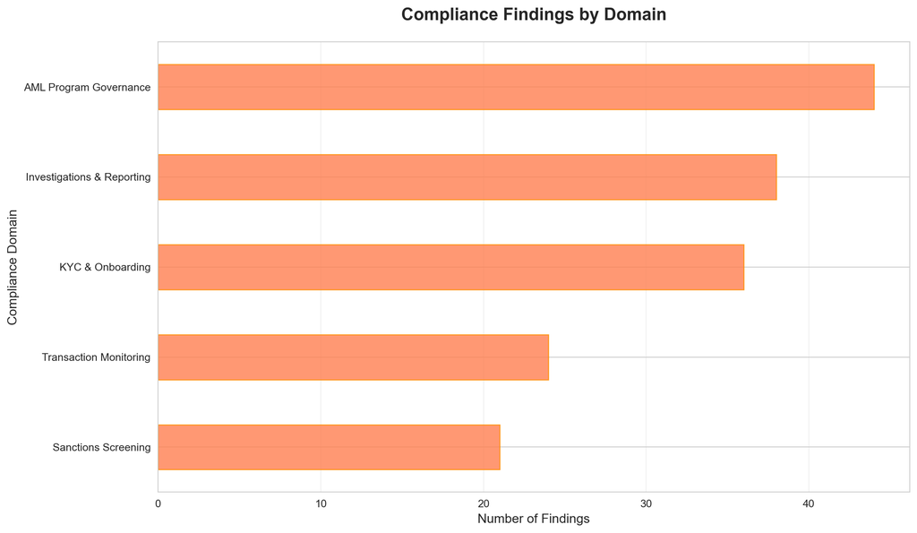

Figure 4: Compliance findings by domain

### Theme Frequency Table

Table 2: Detailed breakdown of compliance themes

| domain_display | Number of Findings | Number of Entities |
| --- | --- | --- |
| AML Program Governance | 44 | 19 |
| Investigations & Reporting | 38 | 20 |
| KYC & Onboarding | 36 | 16 |
| Transaction Monitoring | 24 | 12 |
| Sanctions Screening | 21 | 5 |

## Multi-Domain Violation Patterns

Compliance failures often span multiple domains. Understanding which domains tend to fail together helps identify systemic weaknesses.

Table 3: Co-occurrence of compliance domain failures

|  | Unnamed: 0 | Domain 1 | Domain 2 | Co-occurrences |
| --- | --- | --- | --- | --- |
| 0 | 0 | Investigations & Reporting | KYC & Onboarding | 14 |
| 1 | 1 | Investigations & Reporting | Transaction Monitoring | 11 |
| 2 | 2 | KYC & Onboarding | Transaction Monitoring | 8 |
| 3 | 3 | Investigations & Reporting | Sanctions Screening | 5 |
| 4 | 4 | KYC & Onboarding | Sanctions Screening | 3 |
| 5 | 5 | Sanctions Screening | Transaction Monitoring | 1 |

### Theme Pattern Insights

The most problematic domains by **breadth of impact** are **AML Program Governance**, **Investigations & Reporting**, and **KYC & Onboarding**. AML Program Governance has the highest number of findings (44), indicating foundational weaknesses in oversight, policies, resourcing, escalation, or control ownership. Investigations & Reporting is close behind with 38 findings across 20 entities, making it both highly frequent and widely distributed; this suggests recurring breakdowns in alert disposition, case management, SAR/STR decisioning, and regulatory reporting discipline. KYC & Onboarding also stands out with 36 findings, meaning customer risk identification and due diligence controls are failing at scale. By contrast, Sanctions Screening has fewer entities affected (5) but still 21 findings, which implies that while it is concentrated in fewer firms, the failures may be deep and systemic where they exist.

The multi-domain patterns show that failures are rarely isolated. The strongest linkage is between **Investigations & Reporting and KYC & Onboarding** (14 co-occurrences), followed by **Investigations & Reporting and Transaction Monitoring** (11), and **KYC & Onboarding and Transaction Monitoring** (8). This suggests a common control-chain issue: weak onboarding/KYC leads to poor customer risk profiles, which then undermines monitoring scenarios and makes investigations less effective. The repeated pairing of Investigations & Reporting with both KYC and Transaction Monitoring implies that downstream case handling is often compensating for upstream control gaps, rather than functioning as a separate, resilient layer. Sanctions Screening co-occurs less often, but when it does, it appears alongside the same core domains, reinforcing that sanctions issues may be part of broader program weakness rather than a standalone screening-tool problem.

Prioritization should focus first on **governance and end-to-end control design**, not just individual tools. Firms should (1) strengthen AML governance with clear accountability, KRIs/KPIs, independent QA, and board-level reporting on control failures; (2) fix KYC/onboarding by tightening CDD/EDD standards, beneficial ownership capture, risk scoring, and periodic refresh triggers; and (3) improve investigations and reporting with documented case standards, escalation thresholds, and quality review of SAR/STR decisions. Transaction monitoring should be recalibrated using risk-based scenarios tied to customer profiles, with regular validation and tuning. Sanctions screening should be reviewed for data quality, list-update timeliness, and alert handling, but because it co-occurs less frequently, it should be prioritized in firms where screening issues are observed alongside broader onboarding or monitoring weaknesses.

## Priority Distribution by Domain

The severity of compliance gaps varies across domains, with different distributions of high, medium, and low priority findings.[^2]

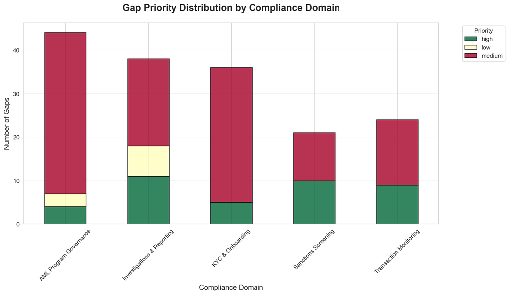

Figure 5: Gap priority distribution across compliance domains

# Root Cause Analysis

Understanding the underlying causes of compliance failures is critical for effective remediation.

## Overall Root Cause Frequency

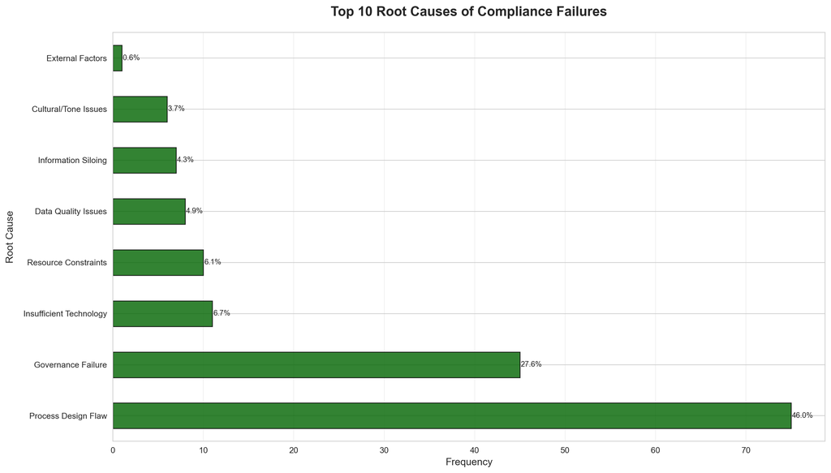

Figure 6: Top root causes of compliance failures

### Root Cause Summary Table

Table 4: Complete root cause frequency distribution

| root_cause | Frequency | Percentage |
| --- | --- | --- |
| Process Design Flaw | 75 | 46.0 |
| Governance Failure | 45 | 27.6 |
| Insufficient Technology | 11 | 6.7 |
| Resource Constraints | 10 | 6.1 |
| Data Quality Issues | 8 | 4.9 |
| Information Siloing | 7 | 4.3 |
| Cultural/Tone Issues | 6 | 3.7 |
| External Factors | 1 | 0.6 |

## Root Causes by Compliance Domain

Different compliance domains exhibit distinct root cause patterns.

Table 5: Cross-tabulation of root causes by compliance domain

| domain_display | Cultural/Tone Issues | Data Quality Issues | External Factors | Governance Failure | Information Siloing | Insufficient Technology | Process Design Flaw | Resource Constraints |
| --- | --- | --- | --- | --- | --- | --- | --- | --- |
| AML Program Governance | 1 | 2 | 1 | 18 | 1 | 1 | 14 | 6 |
| Investigations & Reporting | 3 | 1 | 0 | 10 | 1 | 1 | 19 | 3 |
| KYC & Onboarding | 0 | 2 | 0 | 10 | 2 | 0 | 22 | 0 |
| Sanctions Screening | 2 | 1 | 0 | 7 | 2 | 3 | 6 | 0 |
| Transaction Monitoring | 0 | 2 | 0 | 0 | 1 | 6 | 14 | 1 |

### Root Cause Insights

Across the 24 actions, the typical monetary case was a **$227,700 median penalty**, while the **outlier-excluded total penalties were $14,454,604**; the headline **$289,454,604 total** is heavily skewed by the **Adani Enterprises Limited** action, which alone accounts for **$275,000,000**. Excluding that outlier, the penalty profile is much more modest and better reflects the broader population of cases. There were also **4 non-monetary resolutions**, indicating that not every matter resulted in a financial sanction. The most significant systemic root causes are clearly **Process Design Flaws (46.0%)** and **Governance Failures (27.6%)**, together comprising nearly three-quarters of all cited causes. This suggests the core issue is not isolated employee error, but weak control architecture: unclear ownership, inadequate escalation paths, ineffective review/approval steps, and compliance processes that are not designed to reliably prevent, detect, and remediate breaches.

# Aggravating & Mitigating Factors

Enforcement documents record factors that intensified regulatory concern (aggravating) or earned credit (mitigating). Aggregated across all actions, these reveal what behaviours regulators penalise most and what most reliably reduces exposure.

Table 6: Recorded aggravating vs mitigating factors

| factor_type | Factor Entries | Actions |
| --- | --- | --- |
| aggravating | 89 | 23 |
| mitigating | 47 | 16 |

Across these matters, the dominant aggravating theme is persistence and repetition: many failures lasted multiple years, sometimes across several examination cycles or from 2018 through 2025, and several firms ignored prior warnings or earlier commitments to fix the same issue. A second recurring theme is actual harm, not just technical noncompliance: customer losses, unnecessary surrender fees, unauthorized trading, undisclosed trading costs, missed suspicious transaction reports, weak recordkeeping, and sanctions exposure that allegedly supported prohibited activity all show up repeatedly. A third common aggravator is systemic control failure—deficiencies in AML/CFT pillars, inadequate surveillance, poor supervisory systems, incomplete risk assessments, and failure to test or escalate known red flags. Finally, regulators repeatedly note the absence of meaningful self-correction: no timely self-reporting, no credible acceptance of responsibility, and, in some cases, inconsistent testimony or disregard of prior regulatory feedback. In rough terms, multi-year persistence and control breakdowns appear in a large share of the actions, while actual customer/market harm and ignored warnings are also frequent and heavily weight aggravation.

The mitigating themes are much more consistent and, importantly, more credible when they are concrete and documented. The strongest credit comes from prompt remediation: revised WSPs, enhanced surveillance, updated AML procedures, automated monitoring tools, new escalation thresholds, and cessation of the problematic conduct. Cooperation is another recurring mitigator, especially where firms provide comprehensive documentation, waive privilege, accept stipulations, or conduct thorough independent investigations. Regulators also credit formal undertakings such as senior-management certification, independent reviewers, and paid penalties, though these usually matter less than real operational fixes. Some matters also receive limited credit for narrow scope, small relative volume, lack of prior history, or absence of intent/knowledge, but these are secondary compared with demonstrable remediation. In practical terms, the behaviors that most aggravate regulators are prolonged inaction, repeated red flags, and continued customer or sanctions harm after notice; the behaviors that most reliably earn credit are fast, verifiable fixes backed by testing, governance, and sustained cooperation.

# Additional Thematic Analyses

## Penalty Severity vs Root Cause

Examining whether specific root causes correlate with higher penalties can inform prioritization.

*Penalties allocated proportionally across findings by priority weight (high=3, medium=2, low=1).*

- **Process Design Flaw**: $138,333,258 (60 findings across 20 actions)
- **Governance Failure**: $63,517,612 (36 findings across 20 actions)
- **Insufficient Technology**: $28,956,006 (9 findings across 8 actions)
- **Cultural/Tone Issues**: $28,906,230 (6 findings across 5 actions)
- **Information Siloing**: $28,855,533 (6 findings across 6 actions)
- **Resource Constraints**: $519,205 (6 findings across 6 actions)
- **Data Quality Issues**: $366,759 (5 findings across 4 actions)

## Temporal Patterns

### Violation Period Statistics

- **Average violation duration:** 1373 days
- **Median violation duration:** 1368 days
- **Longest violation period:** 2921 days
- **Shortest violation period:** 29 days

## Strategic Actions by Root Cause

### Governance Failure

1. **Stand up enterprise AML governance with board-linked accountability**: Create a formal governance structure that ties AML/CFT policy ownership, issue management, and escalation thresholds to senior management and board committees. This should include recurring board reporting, named action owners, due dates, and challenge protocols to ensure issues are not just logged but actually resolved.
2. **Implement a unified compliance assurance and control-testing program**: Build a single assurance framework covering risk assessments, control inventories, periodic testing, QA sampling, and independent review across AML, sanctions, investigations, and supervisory controls. The goal is to create consistent evidence of control effectiveness and a repeatable remediation lifecycle with validation of closure.
3. **Establish dynamic risk governance for customers, products, and third parties**: Put in place governance forums and operating routines that periodically recalibrate risk taxonomy, high-risk customer treatment, country risk, and third-party oversight based on typologies, regulatory change, and behavior shifts. This should drive timely updates to controls, monitoring thresholds, and escalation rules before risk becomes systemic.

### Insufficient Technology

1. **Deploy an integrated surveillance and case-management stack**: Replace fragmented tools with a platform that links alerts, case evidence, investigator workflow, QA, and regulatory reporting in one auditable environment. This improves timeliness, reduces manual error, and gives leadership end-to-end visibility into alert-to-filing performance.
2. **Build a centralized data and retention layer for monitoring**: Create a surveillance data mart or equivalent foundation that retains historical events, supports pattern analytics, and provides examiner-ready audit trails. This is essential for tuning scenarios, validating outcomes, and proving that monitoring decisions were based on complete information.
3. **Implement configurable, validated detection engines**: Use technology that supports scenario tuning, model validation, below-the-line testing, and risk-specific surveillance rules across AML, market abuse, sanctions, and trade monitoring. The expected impact is better detection precision, fewer false negatives, and stronger evidence that monitoring is risk-based and controlled.

### Process Design Flaw

1. **Redesign onboarding, CDD, and risk-rating workflows end to end**: Standardize digital onboarding with mandatory data capture, exception handling, periodic refresh, and dynamic customer risk scoring tied to behavior, geography, and adverse events. This reduces inconsistent account opening practices and ensures risk ratings stay current throughout the customer lifecycle.
2. **Automate investigation and reporting workflows with decision governance**: Connect monitoring, case management, evidence collection, legal review, and SAR/STR filing into a single workflow with timestamps, service-level metrics, and QA checkpoints. This improves timeliness, strengthens decision consistency, and creates defensible records for regulators.
3. **Institutionalize regulatory change and policy lifecycle management**: Create a formal process that translates regulatory updates into policy revisions, control changes, training, and attestations with version control and evidence retention. This ensures the program adapts quickly when products, jurisdictions, or typologies change.

# AI Investment Themes

## Top Use Cases by Root Cause

### Process Design Flaw

*Missing controls, poor workflow design, or inadequate compliance procedures.*

1. **(PD-1)** Apply NLP to map WSP text to Rule 2330 obligations and identify missing supervisory procedures, evidence requirements, and escalation triggers. *Technology: Natural Language Processing, Decision Support, Explainable AI*
2. **(PD-2)** Use AI-assisted enterprise risk assessment drafting to map business lines, branch geographies, service channels, and regulatory factors into a structured annual AML risk assessment. *Technology: Process Automation, Generative AI, Natural Language Processing, Explainable AI*
3. **(PD-3)** Use NLP and workflow automation to detect EDD triggers, assemble evidence, and prompt analysts for missing high-risk customer information. *Technology: Natural Language Processing, Process Automation, Decision Support, Generative AI, Explainable AI*

### Governance Failure

*Weak oversight, unclear accountability, or insufficient board/senior management engagement.*

1. **(GF-1)** Use AI to map obligations, controls, issues, and evidence across shared enterprise AML processes and identify accountability gaps. *Technology: Natural Language Processing, Process Automation, Agentic Automation, Graph-Based Learning*
2. **(GF-2)** Use NLP and process automation to map policies, procedures, audit findings, and control evidence into a continuously updated AML control inventory and gap register. *Technology: Natural Language Processing, Process Automation, Decision Support, Explainable AI*
3. **(GF-3)** Apply decision-support analytics to prioritize remediation items by regulatory criticality, dependency, and residual risk for management and board reporting. *Technology: Predictive Analytics, Decision Support, Probabilistic & Causal Methods, Explainable AI*

### Insufficient Technology

*Legacy systems, lack of automation, or inadequate tooling for compliance obligations.*

1. **(IT-1)** Use graph analytics to identify hidden relationships among accounts through shared identifiers, referrals, IPs, funding sources, and trading behavior. *Technology: Graph-Based Learning, Pattern Recognition, Entity Resolution, Explainable AI*
2. **(IT-2)** Detect suspicious low-priced securities liquidation patterns using behavioral anomaly detection combined with market-volume concentration analysis. *Technology: Pattern Recognition, Predictive Analytics, Deep Learning, Explainable AI*
3. **(IT-3)** Detect abnormal post-IPO trading patterns, including concentration, synchronized orders, and rapid price-impact behavior in low-priced securities. *Technology: Pattern Recognition, Predictive Analytics, Deep Learning, Explainable AI*

## Investment Reference Table

Table 7: AI use case investment reference — expected benefit, ROI, and key risks

[output not shown]

# Appendix

## Priority Level Definitions

Priority levels are assigned using a deterministic decision tree applied during document extraction:

- **High** — penalty >$10M attributable to this gap; regulator labelled the conduct “egregious”; gap enabled actual illegal activity; or criminal referral was made
- **Medium** — significant control weakness attracting explicit regulatory criticism; contributed to the penalty but was not the primary driver
- **Low** — documentation or procedural gap only; technical non-compliance with no evidence of exploitation

## Data Sources

> **Currency note:** Q2 2026 penalty amounts arrive **pre-converted to USD** upstream, so the pipeline is run with `--amounts-in-usd` and no run-time FX conversion is applied. This differs from Q1 2026, whose local-currency amounts are converted at run time via `rates.json`. Quarter-over-quarter penalty deltas therefore compare like-for-like on currency but may carry minor exchange-rate noise from the differing conversion timing.
- **Primary Data:** Regulatory enforcement action records (regbriefs-Q22026.csv)
- **Fields Analyzed:** Entity, regulator, industry, penalty amounts, violation periods, findings by domain, root causes, priorities
- **Time Period:** 2014-2026
- **Geographic Coverage:** 6 countries, 10 regulators

## Source Documents

[output not shown]

**Report Generated:** 2026-07-04 12:36:28

**Report Period:** Q2 2026

## Footnotes

[^1]: Findings are discrete compliance gaps identified within each enforcement action document. Each enforcement action may contain multiple findings across one or more compliance domains.
[^2]: See [Appendix: Priority Level Definitions] for the criteria used to assign each priority level.